# Does Meeting the Aerobic Activity Guideline Lower Mortality

A two-act NHANES study on predicting an outcome and changing it

Published

August 26, 2026

## The question

This report examines whether adults who meet the aerobic activity guideline have a lower death rate than adults who do not. It uses six cycles of the National Health and Nutrition Examination Survey from 2007 through 2018, linked to death records through the end of 2019.

The work divides into two acts that answer two distinct questions. The first act only predicts who dies. It asks how well baseline traits forecast death within five years, and nothing more. The second act asks whether the activity itself lowers the risk, which requires separating the effect of activity from the many ways active and inactive adults already differ at baseline.

The estimand is fixed in `protocol.md` before any estimation runs. It is the population average treatment effect on the treated at five years, defined for noninstitutionalized United States adults age 40 and older through the pooled examination weights. Every analysis below is an instance of that specification, and every interval comes from the same replicate construction, so the numbers are comparable.

## Data and cohort

The study cohort comprises adults age 40 and older who were eligible for mortality follow-up and had a known activity level, totaling 22,235 people. The table below shows how the full sample narrows to that group.

| Step | Participants |
| --- | --- |
| all | 59842 |
| age 40 plus | 23226 |
| mortality eligible | 23157 |
| exam follow-up | 22265 |
| exposure known | 22235 |

Some individuals finish the household interview but do not attend the physical examination, so they have no examination date or follow-up time. They exit at the examination follow-up step, which keeps the reported cohort aligned with the one the models run on.

Missing data is minimal. Family income relative to the poverty line is the only field missing for more than a few percent of the cohort. Complete-case deletion of that field remains an open item.

| Variable | Fraction missing |
| --- | --- |
| income_ratio | 0.102 |
| bmi | 0.017 |
| prior_disease | 0.006 |
| education | 0.002 |
| smoke | 0.001 |
| age | 0.000 |

Table 1 is survey weighted, so the described population is the same one the effect estimate refers to. The active group is younger, better educated, higher earning, less likely to smoke, and lighter, and the unadjusted mortality gap is far wider than what the adjusted analysis will report. Closing those gaps is the job of the second act.

```
                           Stratified by met_guideline
                            0                   1                   SMD
  n                         98002038.75         45358340.05
  age (mean (SD))                 58.75 (11.96)       56.27 (11.17)  0.214
  sex = male (%)             43980579.3 (44.9)   23661635.0 (52.2)   0.146
  race (%)                                                           0.165
     Mexican American         6980954.1 ( 7.1)    2273657.2 ( 5.0)
     Other Hispanic           5172071.3 ( 5.3)    1739011.9 ( 3.8)
     Non-Hispanic White      67254365.0 (68.6)   34191740.5 (75.4)
     Non-Hispanic Black      11251507.6 (11.5)    3875308.8 ( 8.5)
     Other or multiracial     7343140.7 ( 7.5)    3278621.6 ( 7.2)
  education (%)                                                      0.602
     Less than 9th grade      8019029.9 ( 8.2)    1270780.1 ( 2.8)
     9th to 11th grade       12960977.0 (13.2)    2124779.4 ( 4.7)
     High school or GED      25337232.9 (25.9)    8191034.2 (18.1)
     Some college or AA      29546065.5 (30.2)   12602932.1 (27.8)
     College graduate        22050842.1 (22.5)   21143863.0 (46.6)
  income_ratio (mean (SD))         2.91 (1.62)         3.72 (1.51)   0.514
  smoke (%)                                                          0.263
     current                 19988334.0 (20.4)    4985206.3 (11.0)
     former                  28689873.7 (29.3)   14165097.8 (31.2)
     never                   49280342.1 (50.3)   26181868.2 (57.8)
  prior_disease (mean (SD))        0.23 (0.42)         0.20 (0.40)   0.054
  bmi (mean (SD))                 30.14 (7.01)        27.96 (5.60)   0.343
  cycle (%)                                                          0.076
     2007-2008               16009753.4 (16.3)    6314545.0 (13.9)
     2009-2010               15652577.8 (16.0)    7255977.1 (16.0)
     2011-2012               15948404.5 (16.3)    7783136.6 (17.2)
     2013-2014               16723726.5 (17.1)    7596279.6 (16.7)
     2015-2016               16465417.7 (16.8)    8322533.4 (18.3)
     2017-2018               17202158.9 (17.6)    8085868.4 (17.8)
  died (mean (SD))                 0.13 (0.33)         0.05 (0.22)   0.264
  follow_months (mean (SD))       76.40 (41.77)       78.64 (40.69)  0.054
```

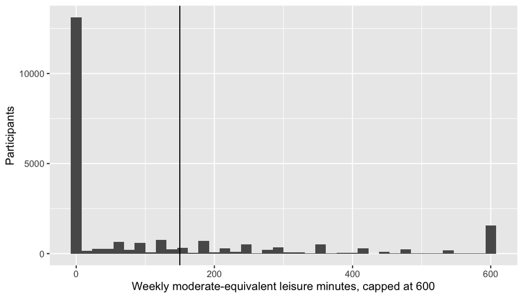

Weekly moderate-equivalent leisure minutes, capped at 600. The line marks the 150-minute guideline.

The cohort builds twice, once in R and once in a DuckDB database from a set of SQL files. A pipeline check compares four counts from the two paths and stops the run on any divergence.

## Act 1, prediction

A random survival forest predicts time to death from baseline traits, including body mass index. It uses each individual’s actual follow-up rather than a fixed five-year label, so participants with shorter follow-up contribute correctly instead of being discarded. The data split into training, validation, and test partitions stratified on the event indicator. The node size is tuned on the validation partition, and the same scoring function used for tuning produces the final test numbers.

Discrimination at five years is 0.8289 by the time-dependent area under the curve, with an out-of-bag concordance of 0.8052. A number like this is uninformative on its own when age is available as a single predictor, so an age-only forest scores through the same function as a reference and reaches 0.7938. The gap between the two is what the remaining predictors buy.

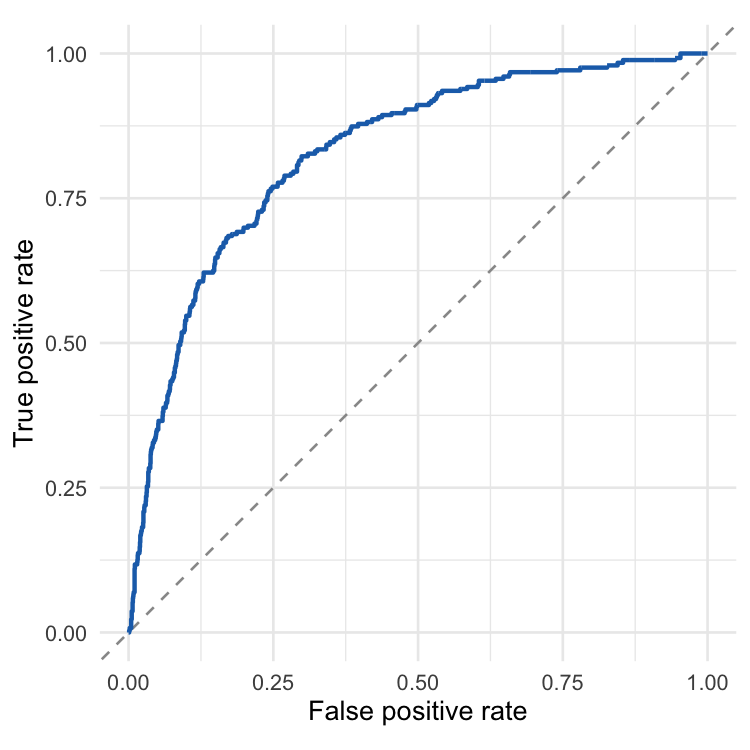

Time-dependent ROC at five years on the test partition.

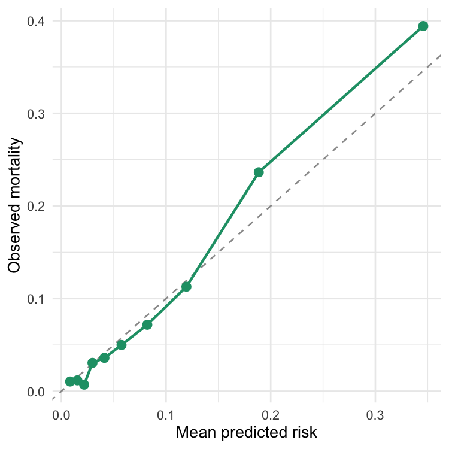

Calibration at five years. Predicted risk against observed Kaplan-Meier risk by decile of predicted risk.

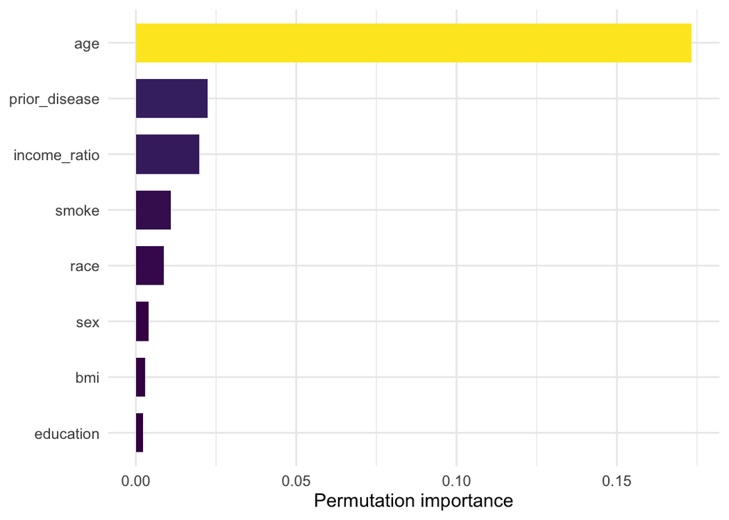

Permutation importance by predictor group.

This act says nothing about cause. A model can forecast death well by leaning on age, and age is not something a person changes to live longer. Strong prediction and a real treatment effect are different claims, and telling them apart is the job of the second act.

## Act 2, the causal effect

The adjustment set is not argued in prose. It derives from the causal diagram below under the canonical criterion, which excludes descendants of the exposure by construction. Body mass index is modeled as a mediator on the path from activity to death, so it stays out of the primary adjustment. Survey cycle is a node with edges to both exposure and outcome, so calendar time enters the adjustment automatically.

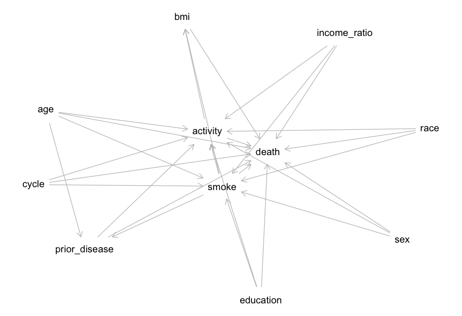

The causal diagram. Both adjustment sets derive from it programmatically.

Entropy balancing reweights the inactive arm to the active arm on the derived adjustment set, with the pooled examination weight supplied as a sampling weight, so the estimate refers to the national population rather than the survey sample. The risk difference is read from the balanced survival curves at five years. The interval comes from Rao-Wu-Yue-Beaumont rescaled bootstrap replicate weights that respect the stratified cluster design, and the balancing model refits inside every replicate.

The primary estimate is a five-year risk difference of -0.0257, with a 95 percent confidence interval from -0.033 to -0.0184. A negative value means lower mortality in the active group.

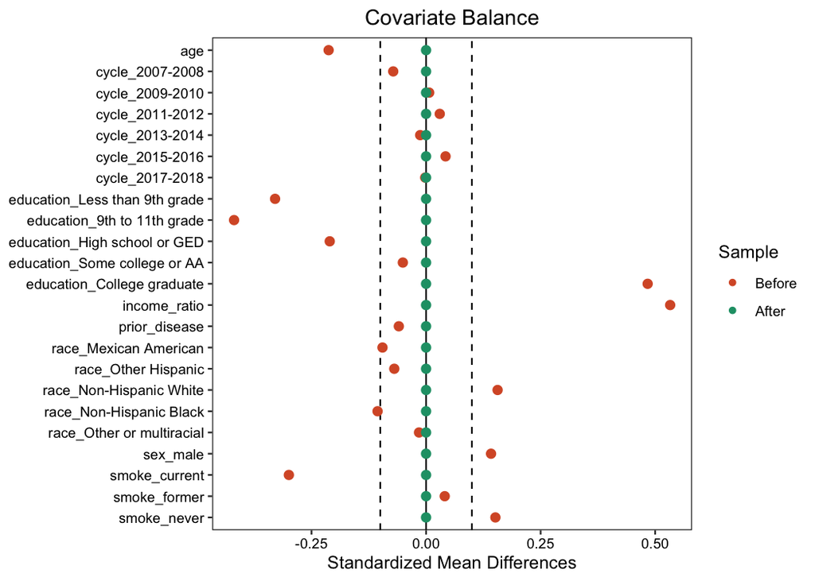

Covariate balance before and after entropy balancing.

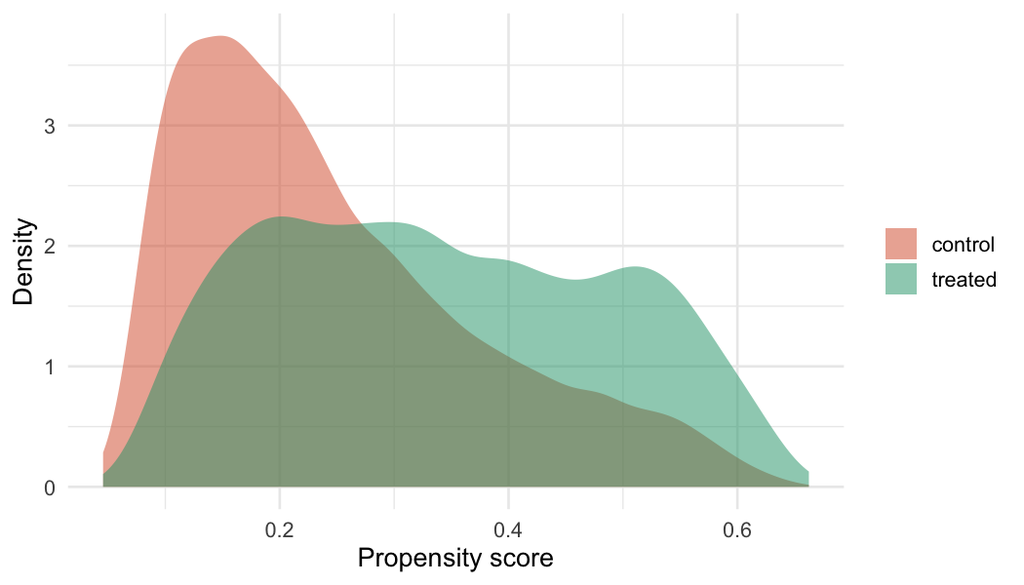

Propensity score overlap between arms, shown as a diagnostic rather than asserted.

The balance plot shows the standardized differences moving from the wide gaps of Table 1 to zero, which entropy balancing achieves exactly on the first moments. The overlap plot shows the two arms sharing support rather than the estimate resting on a thin sliver of the control arm. The effective sizes below are the price of that balance, and they are not small print: the control arm carries far fewer effective observations than its raw count, which is the survey weighting and the balancing compounding. The intervals reflect this, since the balancing model refits inside every replicate.

| Arm | Participants | Effective size |
| --- | --- | --- |
| control | 14487 | 3302 |
| treated | 5348 | 2749 |

## The landmark, co-primary

Reverse causation is the largest threat to this estimate, since frail people are often both less active and close to death. The landmark analysis is therefore co-primary rather than a side check. Participants who died or were censored before 24 months are excluded, follow-up re-anchors at the landmark, and the risk difference is estimated over the following 60 months.

The landmark estimate is -0.0241, with an interval from -0.0369 to -0.0114, against the primary -0.0257. That is 6 percent attenuation, well inside the landmark interval, so the data do not support reading the primary figure as inflated by early deaths. Whatever survives the landmark is much harder to attribute to frailty at baseline, and on these numbers most of it survives.

This is a change from an earlier version of the analysis, which used a two-year washout rather than a landmark and reported roughly a third of the effect disappearing. The two are not the same quantity. The washout dropped early deaths but left follow-up anchored at the examination, so it removed events without removing the person-time in which frailty operates. The landmark re-anchors both, and once it does the attenuation largely goes away. The earlier result is better explained by the mismatch than by reverse causation.

## Falsification and sensitivity

Every check below passes through the same estimand, the same balancing, and the same replicate interval as the primary analysis.

| Analysis | Months | Risk difference | Lower | Upper |
| --- | --- | --- | --- | --- |
| primary | 60 | -0.0257 | -0.0330 | -0.0184 |
| activity_10yr | 120 | -0.0369 | -0.0534 | -0.0203 |
| landmark | 60 | -0.0241 | -0.0369 | -0.0114 |
| positive_control | 60 | 0.0195 | 0.0060 | 0.0329 |
| positive_control | 120 | 0.0581 | 0.0331 | 0.0832 |
| mediator_base | 60 | -0.0224 | -0.0296 | -0.0151 |
| mediator_bmi | 60 | -0.0237 | -0.0313 | -0.0162 |

The positive control runs current against never smokers through the same machinery with its own derived adjustment set, which excludes prior disease because those conditions are downstream of smoking. It recovers a five-year risk difference of 0.0195 that grows to 0.0581 at ten years, so the pipeline detects a known harm and shows it accumulating. The activity contrast reads -0.0369 at ten years.

The negative control turns the machinery on accidental death, where activity has no plausible causal path. Other causes of death are treated as competing events in an Aalen-Johansen estimate rather than as censoring, and decedents with missing cause codes count as competing deaths rather than leaving the analysis. Across 58 accidental deaths the risk difference is 0.0003, with an interval from -0.0012 to 0.0018. The same weights that find a signal on total mortality find nothing where there should be none. The check is weak in one direction: 58 events cannot rule out a bias smaller than the interval width, so a null here is reassurance rather than proof.

The mediator pair reruns the estimate on the subset with measured body mass index, once without it and once with it, so the two fits differ only by the model and not by who is in it. The pair reads -0.0224 against -0.0237, so the conclusion does not turn on whether body mass index is treated as a confounder or a mediator.

The E-value bounds unmeasured confounding. On the risk-ratio scale the estimate is 0.5343, which yields an E-value of 3.1491 for the estimate and 2.41 for the confidence limit nearest the null. A confounder would need at least that strength of association with both activity and mortality, beyond what is already adjusted, to erase the effect.

## Conclusion and limitations

The effect is consistent. It refers to one stated population, it survives the positive and negative controls, and the mediator pair barely moves it. The landmark is the honest headline, and it holds: excluding the first 24 months and re-anchoring follow-up leaves the estimate close to the primary one, which is the strongest single piece of evidence here against reverse causation.

That is not the same as a settled causal estimate. The landmark rules out frailty in the first two years, not confounding by anything unmeasured, and the negative control rests on 58 accidental deaths, which is too few to detect a bias of the size that would matter. The E-value is the more useful bound.

Three limitations remain open by design. Family income is handled by complete-case deletion without a missingness sensitivity analysis. The exposure is dichotomized at 150 minutes per week, which discards most of the information in the measurement. The causal diagram is an assumption whose implied conditional independencies have not yet been tested against the data. This is observational data, so unmeasured confounding cannot be ruled out, and the E-value quantifies rather than removes that concern.

## References

The design and methods follow established work in causal inference and survival analysis, and the question itself builds on a large literature linking activity to mortality.

1. Pearl J, Glymour M, Jewell NP. Causal Inference in Statistics. Hoboken, NJ. Wiley, 2016.
2. Hainmueller J. Entropy balancing for causal effects. Political Analysis. 2012;20(1):25-46. doi:10.1093/pan/mpr025
3. Rao JNK, Wu CFJ. Resampling inference with complex survey data. Journal of the American Statistical Association. 1988;83(401):231-241. doi:10.1080/01621459.1988.10478591
4. Textor J, van der Zander B, Gilthorpe MS, Liskiewicz M, Ellison GTH. Robust causal inference using directed acyclic graphs, the R package dagitty. International Journal of Epidemiology. 2016;45(6):1887-1894. doi:10.1093/ije/dyw341
5. Schisterman EF, Cole SR, Platt RW. Overadjustment bias and unnecessary adjustment in epidemiologic studies. Epidemiology. 2009;20(4):488-495. doi:10.1097/EDE.0b013e3181a819a1
6. Lipsitch M, Tchetgen Tchetgen E, Cohen T. Negative controls, a tool for detecting confounding and bias in observational studies. Epidemiology. 2010;21(3):383-388. doi:10.1097/EDE.0b013e3181d61eeb
7. VanderWeele TJ, Ding P. Sensitivity analysis in observational research, introducing the E-value. Annals of Internal Medicine. 2017;167(4):268-274. doi:10.7326/M16-2607
8. Ishwaran H, Kogalur UB, Blackstone EH, Lauer MS. Random survival forests. Annals of Applied Statistics. 2008;2(3):841-860. doi:10.1214/08-AOAS169
9. Arem H, Moore SC, Patel A, et al. Leisure time physical activity and mortality, a detailed pooled analysis of the dose-response relationship. JAMA Internal Medicine. 2015;175(6):959-967. doi:10.1001/jamainternmed.2015.0533